# Izpit Podatkovno Programiranje (90 min)

Ime in priimek

2024-05-31

## Uvod

Oddana naloga mora biti pretvorjena v html, kjer je razvidna koda in rezultat kode. Drugih oblik oddaje ne bom upošteval!!!

## Naloga 1 (3 tocke)

Naključno generirajte 100 **celih** števil med -40 in 40. Prikažite porazdelitev vrednosti s histogramom. Histogram naj ima naslov “Porazdelitev nakljucnih vrednosti”.

```r
library(tidyverse)
```

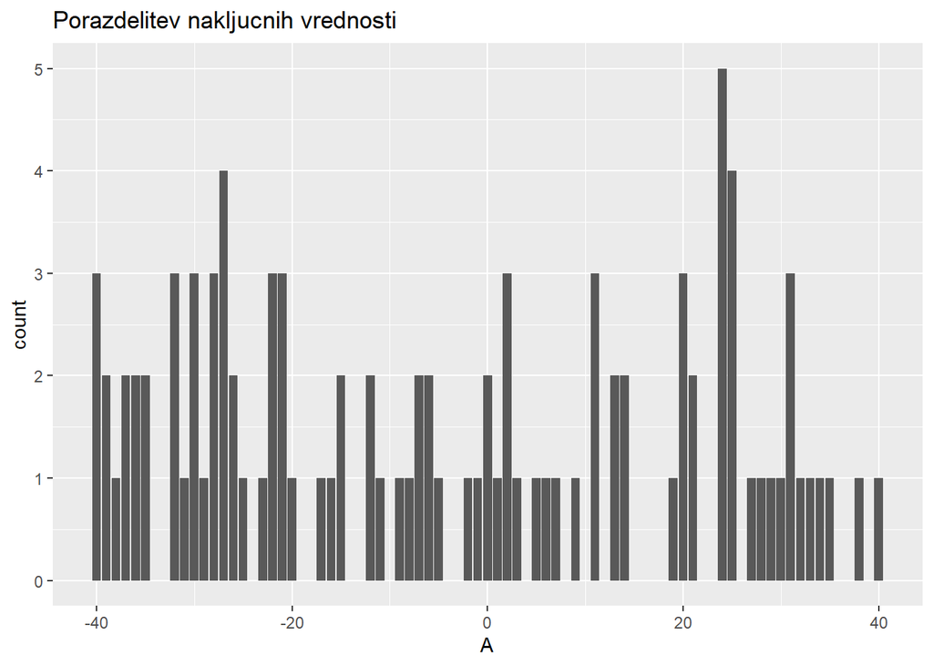

```r
sample(-40:40,100,replace=T) %>%
  data.frame(A=.) %>%
  ggplot()+
  aes(x=A)+
  geom_bar()+
  labs(title="Porazdelitev nakljucnih vrednosti")
```

## Naloga 2 (3 tocke)

Nakljucno generirajte 1000 **celih** stevil med 1 ter 10000. Koliko stevil je lihih in koliko je sodih?

```r
sample(1:10000,1000,replace=T) %>%
  {c(Soda=length(.)-sum(.%%2),Liha=sum(.%%2))}
```

```
## Soda Liha
##  498  502
```

## Naloga 3 (5 tock)

S pomocjo funkcije letters generirajte besedo s 50 crkami. Beseda ne sme biti sestavljena samo iz ene crke!!! S stolpicnim grafom prikazite frekvenco posameznih crk.

```
## [1] "pzjayogzmencacyzytjkoxqegkwcifmdyzwykbnoikkswbozqd"
```

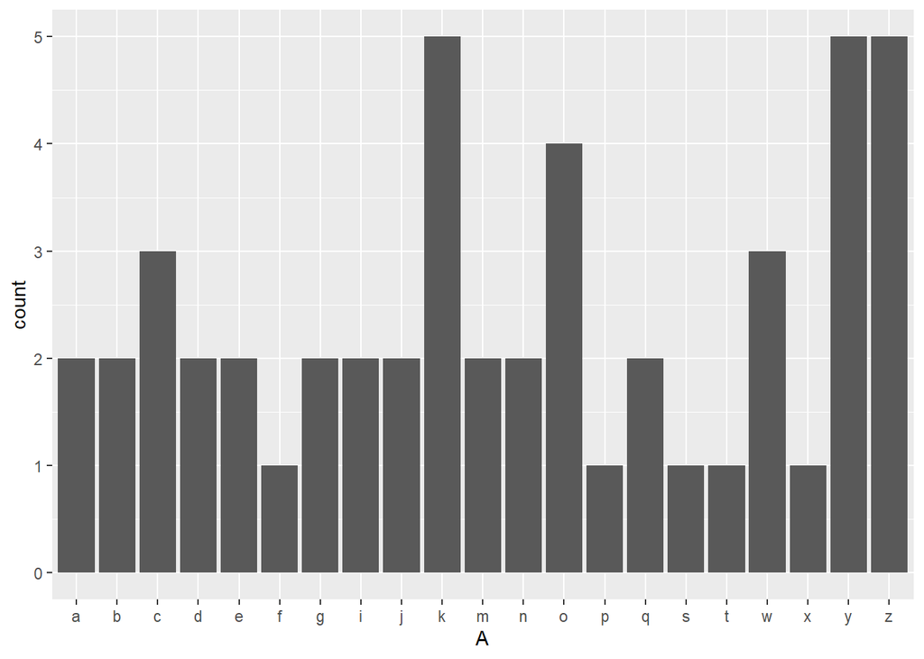

```r
letters %>%
  sample(50,replace=T) %>%
  paste(collapse = "") %>%
  {print(.);.} %>%
  str_split("") %>%
  unlist() %>%
  data.frame(A=.) %>%
  ggplot()+
  aes(x=A)+
  geom_bar()
```

## Naloga 4 (3 tocke)

Pretvorite data.frame grades is wider to longer obliko s pomocjo funkcije pivot_longer, kjer bosta stolpca math ter history shranjena v stolpec z imenom “predmet”, ocene pa v stolpcu z imenom “ocena”.

```r
grades <- data.frame(names = c("John", "Juan", "Jean", "Yao"),
                     math = c(95, 80, 90, 85),
                     history = c(90, 85, 85, 90))
grades %>%
  pivot_longer(math:history,names_to="predmet",values_to="ocena")
```

```
## # A tibble: 8 × 3
##   names predmet ocena
##   <chr> <chr>   <dbl>
## 1 John  math       95
## 2 John  history    90
## 3 Juan  math       80
## 4 Juan  history    85
## 5 Jean  math       90
## 6 Jean  history    85
## 7 Yao   math       85
## 8 Yao   history    90
```

## Naloga 5 (5 tock)

Namestite paket library(“dslabs”) ter ga nalozite v pomnilnik. S tem boste pridobili dostop do data.frame murders. S pomocjo tidyverse slovnice odgovorite na naslednja vprasanje, in sicer, kaksen je odstotek umorov glede na populacijo po regijah. Rezultate razvrstite padajoce po odstotku. Kasen je ta odstotek po prvi crki drzave?

```r
library(dslabs)
dslabs::murders %>%
  group_by(region) %>%
  summarise(Pop=sum(population),Murders=sum(total)) %>%
  mutate(Odstotek=Murders/Pop*100) %>%
  arrange(desc(Odstotek))
```

```
## # A tibble: 4 × 4
##   region              Pop Murders Odstotek
##   <fct>             <dbl>   <dbl>    <dbl>
## 1 South         115674434    4195  0.00363
## 2 North Central  66927001    1828  0.00273
## 3 West           71945553    1911  0.00266
## 4 Northeast      55317240    1469  0.00266
```

```r
dslabs::murders %>%
  mutate(Prva=str_sub(state,1,1)) %>% # ali str_extract(state,".)
  group_by(Prva) %>%
  summarise(Pop=sum(population),Murders=sum(total)) %>%
  mutate(Odstotek=Murders/Pop*100) %>%
  arrange(desc(Odstotek))
```

```
## # A tibble: 19 × 4
##    Prva       Pop Murders Odstotek
##    <chr>    <dbl>   <dbl>    <dbl>
##  1 D      1499657     137 0.00914
##  2 L      4533372     351 0.00774
##  3 S      5439544     215 0.00395
##  4 G      9920000     376 0.00379
##  5 P     12702379     457 0.00360
##  6 M     38782746    1341 0.00346
##  7 F     19687653     669 0.00340
##  8 T     31491666    1024 0.00325
##  9 A     14797902     479 0.00324
## 10 C     45857249    1419 0.00309
## 11 V      8626765     252 0.00292
## 12 N     46280611    1241 0.00268
## 13 K      7192485     179 0.00249
## 14 O     19118929     457 0.00239
## 15 I     23928371     539 0.00225
## 16 R      1052567      16 0.00152
## 17 W     14828146     222 0.00150
## 18 U      2763885      22 0.000796
## 19 H      1360301       7 0.000515
```

## Naloga 6 (4 tock)

S pomocjo regular expressiona iz texta:

- pridobite vsa imena

- pridobite vsa stevila

```r
text<-"Drew has 3 watermelons, Shawn has 4 hamburgers, Karina has 12 tamales, and Anna has 6 soft pretzels"

text %>%
  str_extract_all("[A-Z][a-z]*") %>%
  unlist()
```

```
## [1] "Drew"   "Shawn"  "Karina" "Anna"
```

```r
text %>%
  str_extract_all("[0-9]+") %>%
  unlist()
```

```
## [1] "3"  "4"  "12" "6"
```

## Naloga 7 (3 tocke)

Kaksna je razlika v dnevih med datumoma?

```r
x <- "11 th april 2012"
y <- "April 24th 2018 11:59:59"

as.Date(mdy_hms(y))-dmy(x)
```

```
## Time difference of 2204 days
```

## Naloga 8 (4 tocke)

Kreirajte funkcijo, ki iz celoštevilskega vektorja vrne enice med 0 ter 9, ki niso prisotne v vektorju.Npr. Ce je X=10 22 34 148, funkcija vrne 1 3 5 6 7 9.